# POU33201: Authoritarianism — lecture notes

Week 1: What Is Authoritarianism? — 2026-09-18

Print this before the lecture and write on it. The shaded blocks are the parts that need to make sense on their own — the slides in the room are deliberately sparser than this.

## Welcome

To Authoritarianism

## Authoritarianism is lots of things

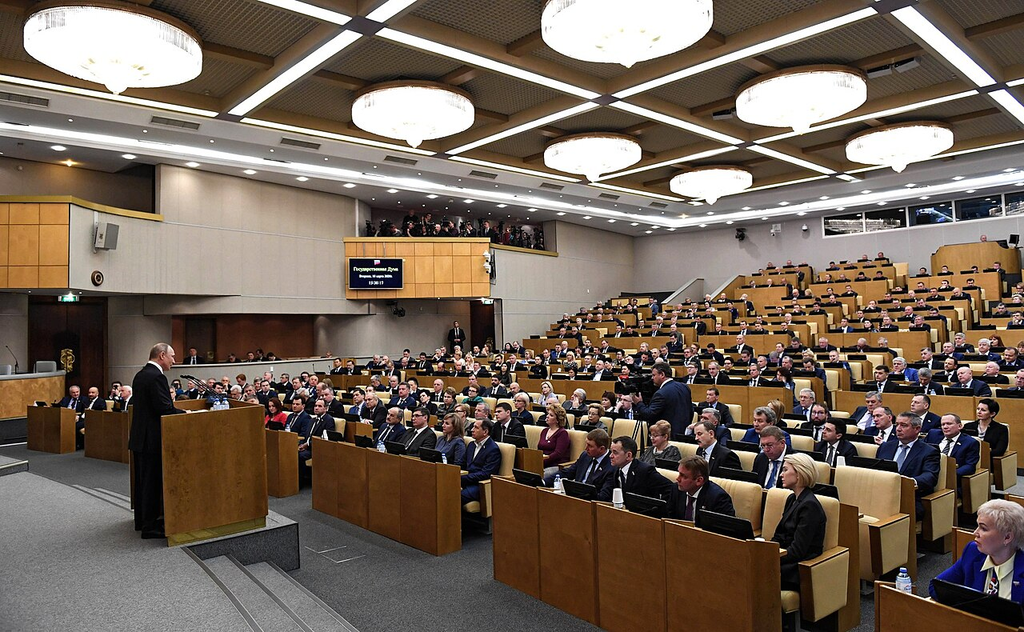

[figure not shown]

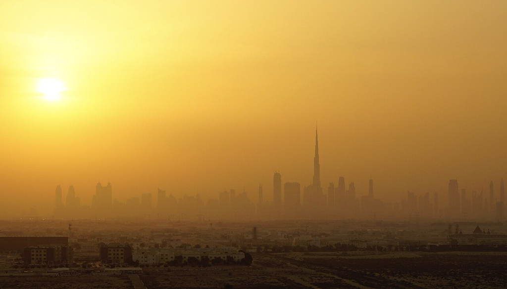

[figure not shown]

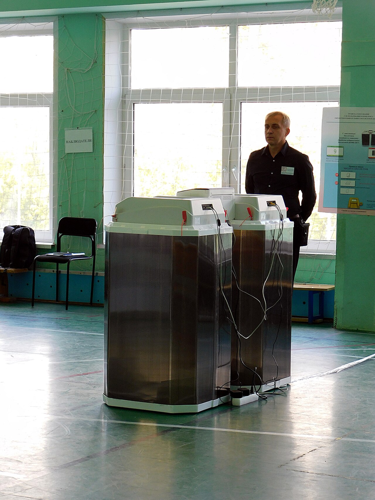

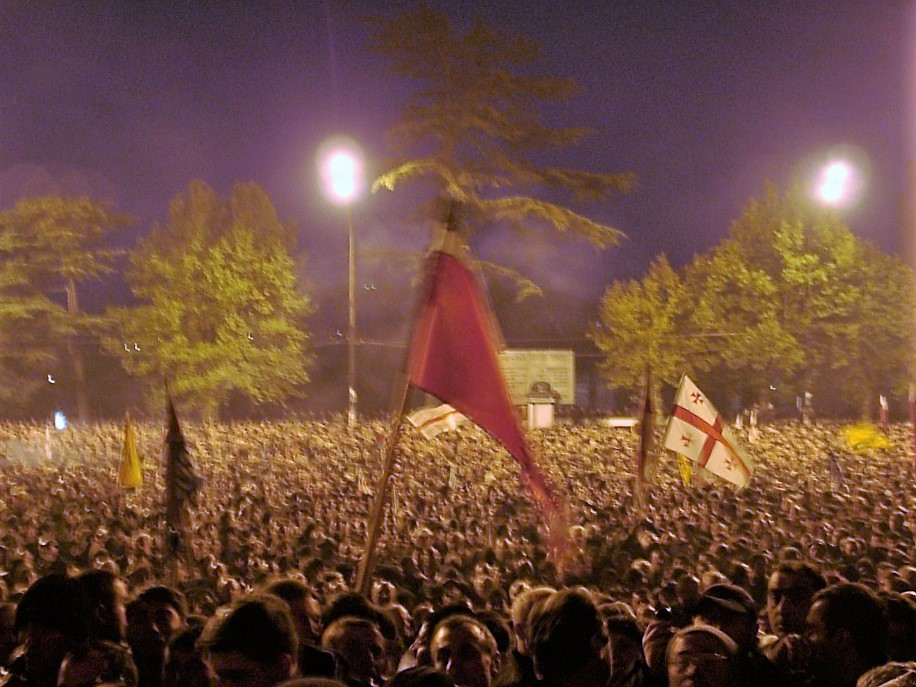

## Today

- What this module is, and what I want from you
- What is democracy? What is authoritarianism?
- Most of the world is not free, and it’s getting less so (is it?)
- Dictators face at least *two* big problems
- After the break: who I am, who you are, how the module runs

## Which of these five is a democracy?

Russia. Hungary. Singapore. Mexico (1990s). The United States.

## How the world’s regimes have changed

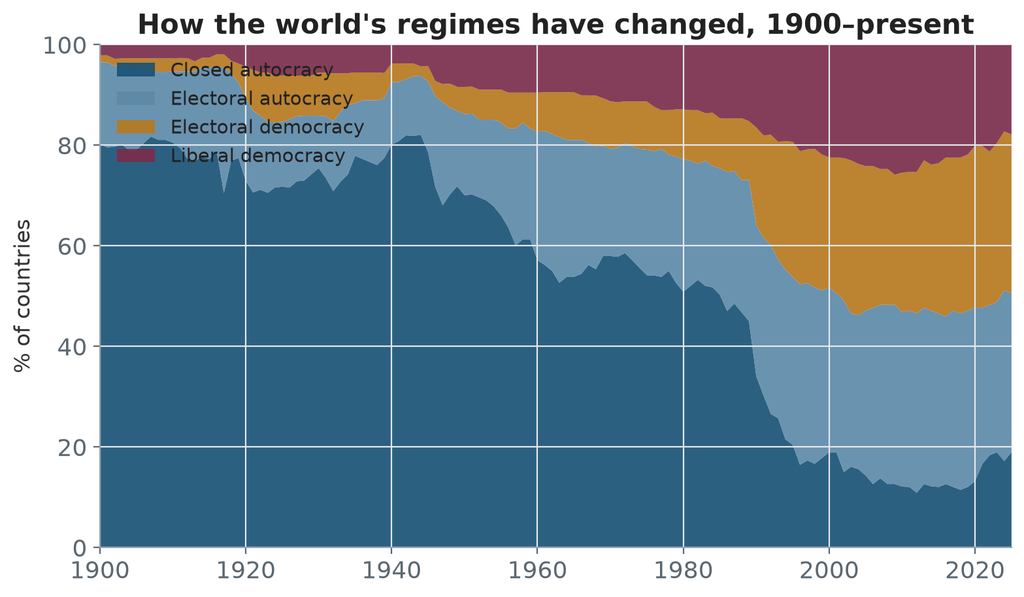

## Most of the world is not free

**74%** of the world’s population lives under some form of autocracy — and **46%** under an *electoral* autocracy, now the most common regime type.

That share has been **rising** for about fifteen years — the “third wave of autocratization” you’ll meet properly in week 12.

So: three of your five guesses were “authoritarian” by most measures.

## What people *think* they know about dictators

> “It’s all about one evil guy at the top.”

> “Dictators rule purely through fear.”

> “Elections in dictatorships are meaningless theatre.”

> “They’re irrational — or just crazy.”

> “They’re always one push from falling over.”

We’ll spend twelve weeks complicating each of these.

## Goals of this module

- **How** do dictatorships actually *work*? Who really holds power?
- **Why** are so many of them so *durable*?
- What **tools** do autocrats use — and what do the tools cost them?
- How do dictatorships **end** — and what comes next?

And underneath: get better at political science by taking non-democracies seriously as *political systems*, not as pathologies.

## Why study dictatorship?

- It’s where most people live — and where the century’s biggest stories are
- It’s a **puzzle**: ruling without consent should be hard. Why isn’t it?
- It sharpens our theory of politics *everywhere* — including democracies
- Democracies can **slide** toward it. Hold that thought until week 12

The puzzle deserves stating plainly. A democratic government has an obvious answer to “why do people obey you?” — they chose you, and can un-choose you. An authoritarian government has no such answer, yet many of them last for decades, tax, conscript, build, and are obeyed by millions who were never asked. The comparative politics of authoritarianism is the attempt to explain that without resorting to “fear” (which turns out to be expensive and unreliable) or “culture” (which explains nothing that varies over time).

## Authoritarianism and political science

This module touches most of political science:

- **Regimes** — what is a democracy, and who decides?
- **Institutions** — parties, parliaments, elections, courts (yes, in dictatorships)
- **Political economy** — rents, patronage, oil, corruption
- **Coercion and information** — repression, propaganda, censorship, surveillance
- **Collective action** — protest, revolution, why nobody saw 1989 coming

## Are dictatorships good at anything?

Growth? Order? Getting things done?

## So what *is* authoritarianism?

Where’s the line — and who gets to draw it?

## How people used to sort regimes

For two thousand years the question was **who rules, and for whom**:

|  | For the common good | For themselves |
| --- | --- | --- |
| **One** | monarchy | tyranny |
| **Few** | aristocracy | oligarchy |
| **Many** | “polity” / mixed regime | democracy (the mob) |

We threw out the second axis. Not because it’s unimportant — because nobody can *code* “rules for the common good” without picking a side.

Plato, Aristotle and Polybius sorted regimes by two questions — how many rule (one, few, many) and whether they rule in the common interest or their own — and the medieval and early-modern writers (Aquinas, Bodin, Machiavelli) kept the scheme. Modern political science dropped the normative axis, because “does this regime serve the common good?” cannot be answered by a neutral coder, and kept only structure: how the people at the top are chosen and whether they can be removed. That is why “authoritarian” ended up as a residual category — everything that is not an electoral democracy — rather than a positive description. The residual is a choice with a history, not a definitional accident.

## Democracy vs. non-democracy — where’s the line?

What’s the *minimum* a regime needs to count as a democracy?

- Free and **fair** elections?
- More than one party that could actually win?
- Rights — speech, press, assembly?
- The losers actually **hand over power**?

Authoritarianism is, in part, a **residual** category: whatever fails the test.

Robert Dahl’s two dimensions are the standard way of thinking about this. *Contestation* asks whether the government can actually be opposed and replaced through elections; *participation* asks how much of the adult population is allowed to take part. A regime can be high on one and low on the other (the nineteenth-century British parliament was highly contested among a tiny electorate; the Soviet Union had universal suffrage and no contestation). “Polyarchy”, Dahl’s word for real-world democracy, is high on both.

## One working definition

> An **authoritarian regime** is one in which rulers acquire and hold power by means other than free and fair multiparty competition — and are not reliably constrained by it.

Nothing here about how *brutal*, how *popular*, or how *stable* the regime is. Those are things to **explain**, not assume.

This is close to the “minimalist” definition used by Przeworski and colleagues and adopted by Svolik: a country is a dictatorship if it fails at least one of two tests — the legislature is chosen in free, competitive, multiparty elections, and the chief executive is either chosen that way or by a legislature chosen that way. The definition is deliberately thin. It says nothing about rights, repression, ideology or popularity, which is exactly what lets us treat those as variables to be explained rather than as part of the label.

## Linz brings the definition

> “…political systems with **limited, not responsible, political pluralism**; without elaborate and guiding ideology (but with distinctive **mentalities**); without intensive nor extensive political **mobilization** (except some points in their development); and in which a leader (or occasionally a small group) exercises power within **formally ill-defined limits but actually quite predictable ones**.”

— Juan Linz, *Totalitarian and Authoritarian Regimes*

## Thick or thin?

Two ways to define things – thick and thin:

- **Thin** (Przeworski, Svolik): fails the election test → dictatorship. Clean, codable, says nothing about *how* it rules.
- **Thick** (Linz): a whole style of rule — limited pluralism, mentality not ideology, demobilised society.

We’ll generally use the thin one to *count* and the thick one to *describe*. Both are choices, and the choice has consequences — that’s week 2.

Why does the choice matter? A thin definition puts North Korea, Saudi Arabia, Singapore and 1990s Mexico in the same box, which is useful for counting and for statistical work but hides everything interesting about how they differ. A thick definition captures the texture of rule but is hard to apply consistently — two coders will disagree about “distinctive mentalities”. Most of the field now uses a thin definition to draw the boundary and a typology (week 2) to sort what falls inside it.

## Totalitarian, authoritarian — or neither?

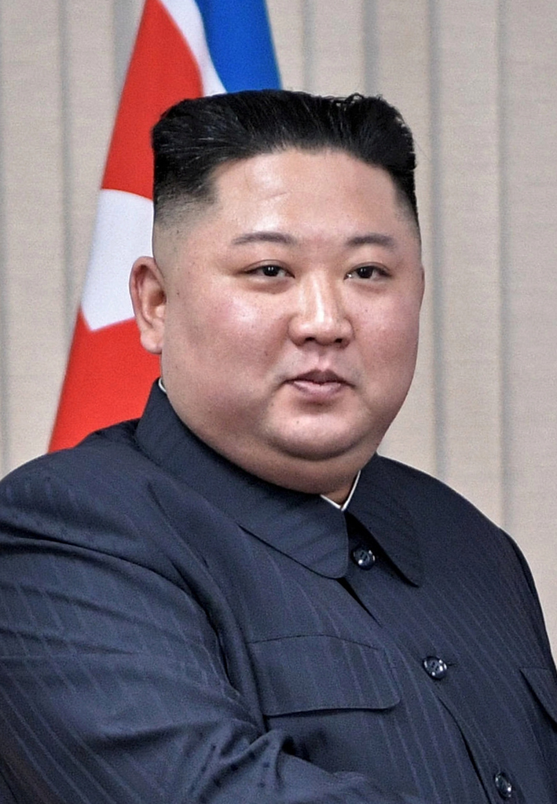

Linz’s other distinction. According to his definition, **totalitarian** regimes have:

- a single, official, all-explaining **ideology**
- a mass party that **mobilises** everyone, all the time
- no tolerated pluralism — not even in a chess club

Is North Korea totalitarian? Is China? Was the USSR in 1985?

## What’s the *one thing* keeping your dictator in power?

Think of a country you’d call authoritarian. Fear, money, ideology — or something else?

## The whole course in one idea

Every autocrat faces **two problems** (Svolik):

- **Power-sharing** — controlling your *allies*, who could replace you
- **Control** — controlling the *masses*, who could rise against you

Almost everything we study — parties, elections, repression, propaganda, coups — is a **tool for managing one of these two problems.**

Svolik’s framing is the spine of the module. The “problem of authoritarian power-sharing” is the dictator’s relationship with the people who put and keep him in power — generals, party bosses, oligarchs, a royal family — who could remove him and whom he cannot credibly promise to reward, because nobody can enforce a promise against a dictator. The “problem of authoritarian control” is his relationship with everybody else, who vastly outnumber him. Historically the first problem has been the more dangerous: far more dictators have been removed by insiders than by uprisings.

## Every week, the same question

Is this week’s tool for the **elites** or for the **masses**?

| Weeks | Tool | Mostly for… |
| --- | --- | --- |
| 3 | Ruling coalitions, commitment problems | elites |
| 4 | Repression, secret police | masses (and elites) |
| 5 | Parties, parliaments, patronage | elites |
| 6 | Elections | masses — and elites |
| 8–9 | Propaganda, censorship, surveillance | masses |
| 10 | Coup-proofing | elites |
| 11–12 | Protest, breakdown, backsliding | when the tools fail |

## Not all dictatorships are alike

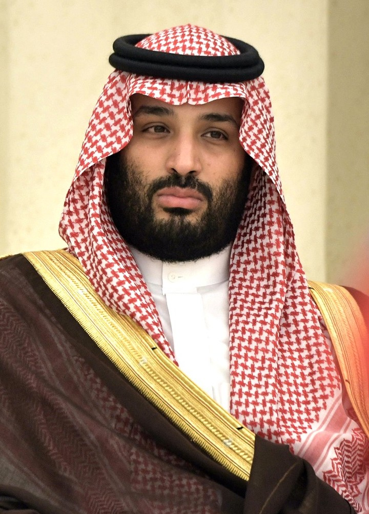

We’ll spend week 2 on the varieties. A preview:

- **Personalist** — one leader, thin institutions: Russia today
- **Single-party** — the party runs the show: China
- **Military** — the officers rule: Egypt since 2013
- **Monarchy** — hereditary rule: Saudi Arabia
- **Electoral authoritarian** — real elections, unfair ones: many, including several from the cold-call

## Cases we’ll keep returning to

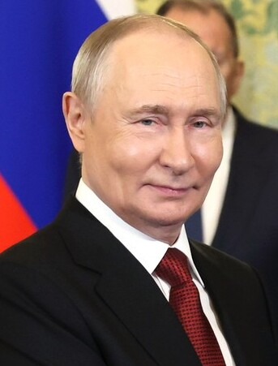

[figure not shown]

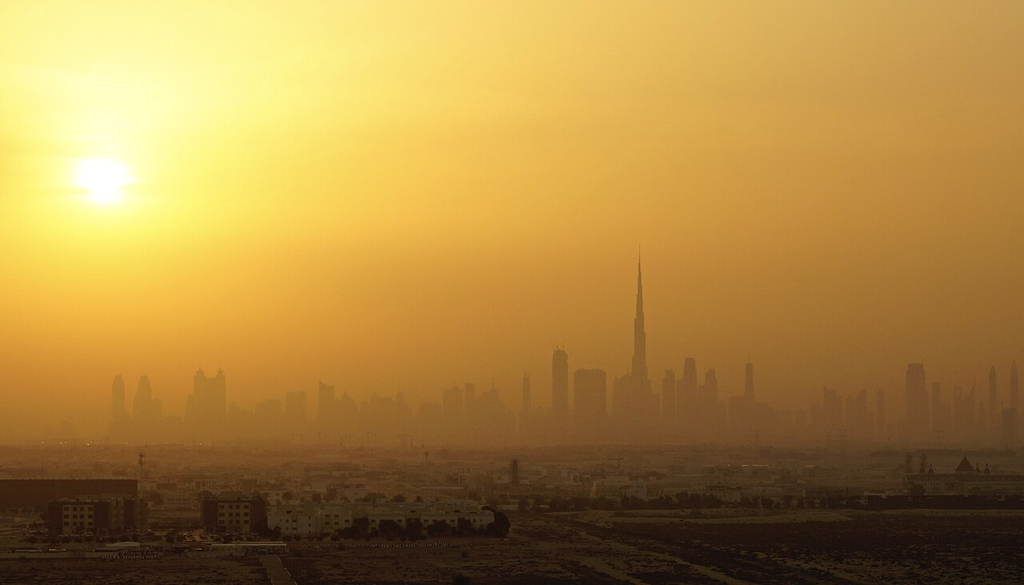

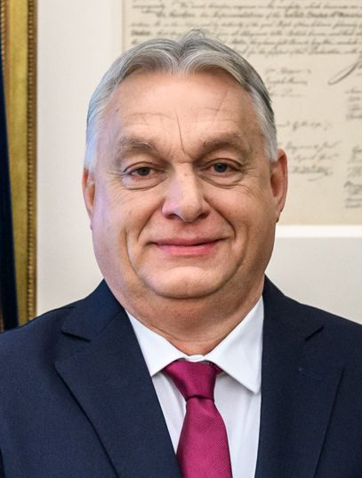

**Russia · China · the Gulf and the wider Middle East · Latin America · Africa · and Europe’s backsliders**

Different regions, same underlying questions.

## Who am I?

- From Minnesota, by way of a lot of time in Russia and the post-Soviet region
- Political scientist working on **Russian politics, authoritarianism, and corruption**
- Quantitative research, public opinion surveys, elites
- Fieldwork **in Russia** — before the war made that a very different question

## How would you measure support for a dictator?

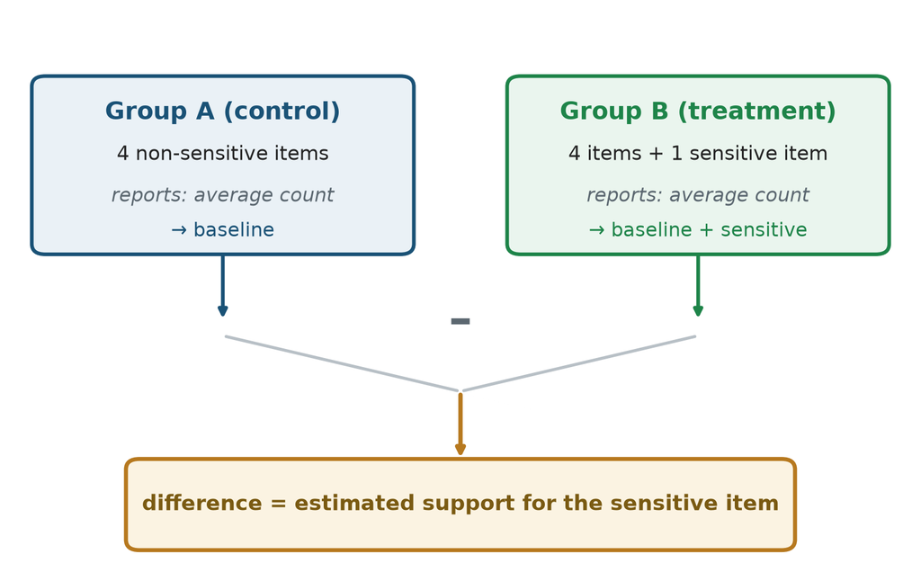

Send in a pollster and ask? If honesty is risky, people say what’s safe.

**The list experiment:** half the sample counts four harmless items; the other half counts the same four plus “the president”. Compare the averages.

No individual ever admits anything. The truth shows up only in the aggregate.

The problem with asking directly in a repressive setting is not that people lie randomly but that they lie in a predictable direction — toward whatever is safe to say to a stranger. A list experiment gets round this by never asking about the sensitive item on its own: respondents report only *how many* items on a list apply to them, and the difference in average counts between a group that saw the sensitive item and a group that didn’t estimates how common it really is. This method returns in week 6 (elections), week 8 (propaganda) and week 11 (protest).

## And who might you be?

- Your name
- Where you’re from
- Why this module — and is there a regime you know something about?
- Did you take Comparative Politics last year?

## Where we’re going

| Wk | Part | Topic |
| --- | --- | --- |
| 1 | Foundations | What is authoritarianism? |
| 2 | Foundations | Varieties of autocracy |
| 3 | Dilemmas | How autocrats take and hold power |
| 4 | Dilemmas | The control problem: repression |
| 5 | Strategies | Buying loyalty: parties, parliaments & patronage |
| 6 | Strategies | Elections without democracy |
| 7 | — | *Reading week — no lecture* |
| 8 | Strategies | Propaganda & censorship |
| 9 | Strategies | Digital authoritarianism |
| 10 | Breakdown | Coups & the military |
| 11 | Breakdown | Protest, revolution & breakdown |
| 12 | Breakdown | Demise, democratization & “autocracy at home?” |

## How this module works

- **One two-hour lecture** a week, Fridays 14:00–16:00 — with a break
- The arguing happens **in here** — discussion, most weeks
- **Response papers (10%)** — short, before the lecture, two across the term
- **Mid-term essay (30%)** — due Sunday 1 November
- **Exam (60%)** — in person, end of term, the whole module

Everything is on the module page and Blackboard.

## Discussion — what that actually means

- Discussion happens **here**
- Response papers are due **before** the lecture they attach to
- Do the reading! The lecture assumes it and the exam will reward it

## The mid-term essay

Due **Sunday 1 November, 23:59**. Set questions, released in due course.

## The exam

- **60%**, in person, end of term, scheduled centrally
- Covers the **whole module**

## Generative AI

If you use it, use it to help you **orient yourself** and to fix prose **you wrote**. Not to do the thinking or write the prose.

- Each assessment’s sheet says exactly what’s allowed
- Every written submission needs the School’s **Assignment Submission Form** as page 1, GenAI disclosure filled in. No form, no submission
- The exam is in person; nothing to declare

## What I want from you

- **Read before class.** The lectures assume this
- Bring the **comparison** — “but in China…”, “but Egypt did the opposite…”
- Be willing to have your priors challenged
- **Read the news.** I’m begging you!!

## Where to follow this stuff

- **Russia:** Meduza (meduza.io/en), *The Moscow Times*, Mark Galeotti’s *In Moscow’s Shadows* podcast
- **China:** China Media Project, *ChinaFile*
- **Everywhere:** *The Financial Times*, *The Economist*

Bring a story. We’ll often try to talk about “what happened this week that belongs in this module?”

## Duma as I say, not as I Duma

- **Russia is holding elections** right now!
- Elections to the lower house of parliament, the State Duma, being held over the weekend
- Along with many regional and local elections
- Why do authoritarian regimes hold elections?? Isn’t Putin’s party, United Russia, guaranteed to win?
- I think they are still very informative and interesting

## An authoritarian country in the EU?

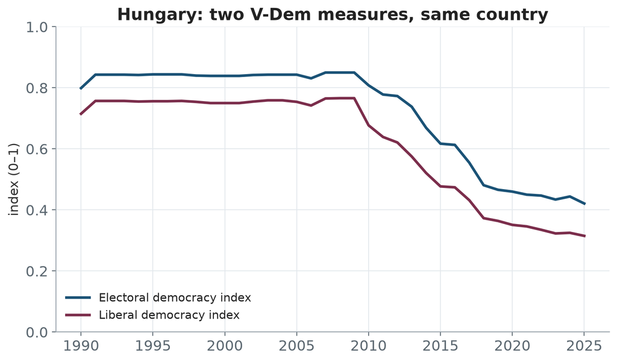

Was Hungary a democracy under Orban? Depends who you ask!

Week 2: how regimes are measured and categorized

## Key readings this week

**Required:**

- Frantz, *Authoritarianism: What Everyone Needs to Know* (2018), pp. 1–13
- Guriev & Treisman, “Informational Autocrats,” *Journal of Economic Perspectives* (2019)

**Recommended:**

- Linz, *Totalitarian and Authoritarian Regimes* (2000), ch. 1
- Geddes, Wright & Frantz, *How Dictatorships Work* (2018)
- Dahl, *Polyarchy* (1971)
- Linz & Stepan, *Problems of Democratic Transition and Consolidation* (1996), ch. 3
- Friedrich & Brzezinski, *Totalitarian Dictatorship and Autocracy* (1956)

## For next week

**Week 2 — Varieties of autocracy**

**Read:**

- Frantz, *Authoritarianism: What Everyone Needs to Know* (2018), ch. 5
- Levitsky & Way, “Elections Without Democracy: The Rise of Competitive Authoritarianism” (2002)
- Svolik, *The Politics of Authoritarian Rule* (2012), chs. 1–2 (pp. 1–45)

**Think about:** pick a country you’d call a dictatorship. What *kind* is it, and could you defend that label against someone who disagreed?

**What today covered.** Authoritarianism is, on a thin definition, whatever fails the test of free and fair multiparty competition; on Linz’s thick definition, a style of rule with limited pluralism, mentalities rather than ideology and a demobilised society. Nearly three-quarters of the world’s population lives under one, and the share has been rising for over a decade. The module’s spine is Svolik’s two problems — power-sharing with the elites who could replace the ruler, and control of the masses who could rise against him — and every tool we study from week 3 onward is an answer to one of them.

**POU33201: Authoritarianism** · Dr Noah Buckley · Trinity College Dublin · MT2026  
Slides and readings: noahbuckley.me/teaching/pou33201-mt2026